# Package Gtsummary

25/05/2024

## Plan

- *Préliminaire*: Utilité, types de variables, données
- *Tableau descriptif univarié*
- *Tableaux croisés*
- *tbl_custom_summary_*
- *Regression logistique binaire*
- *Résumé*

## Préliminaires

## Utilité

Le package `gtsummary` en R est un outil puissant conçu pour la génération de tableaux de synthèse de données statistiques de manière élégante, personnalisable, reproductible et directement publiables. Il intègre :

- *Tableaux descriptifs* : univariés, bivariés et de regression
- *Résumés des données descriptives* : moyennes, médianes, écarts-types, fréquence …
- *Test statistiques* : t-test, khi-2…
- *Personnalisation avancé* : apparence, titres, légendes, annotations …
- *Reproductibilité* : Automatisation

## Installation et types de variables

### Installation

- Installer depuis le CRAN :

```r
  install.packages("gtsummary")
```

- Installer la version de dévellopement depuis github

```r
remotes::install_github("ddsjoberg/gtsummary")
```

### Types de variables

Il y’a trois types de variables dans gtsummary. Par défaut, gtsummary considère qu’une variable est :

- *Dichotomique*: s’il s’agit d’un vecteur logique (TRUE/FALSE), d’une variable textuelle codée yes/no ou d’une variable numérique codée 0/1.
- *Catégorielle*: S’il s’agit d’un facteur, d’une variable textuelle ou d’une variable numérique ayant moins de 10 valeurs différentes.
- *Continue*: Dans les autres cas de variables numériques.

## Description de la base de données

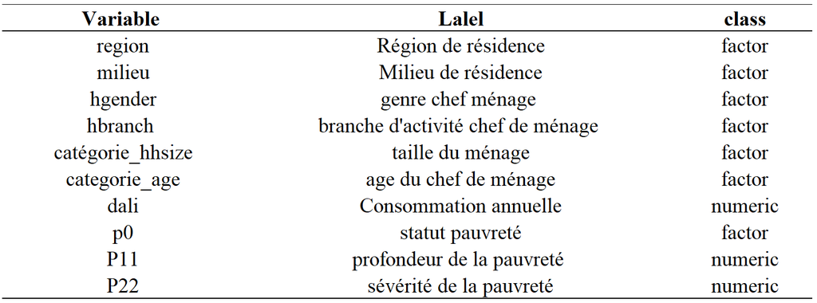

## Tableau descriptif univarié

## Tableeau descriptif univarié

```r
tf <- tempfile("example", fileext = ".docx")



tbl <- basev %>%
  tbl_summary(include = c(milieu,hgender,dali),
              missing = "always",
              missing_text = "Nbre observations manquantes",
              sort = all_categorical() ~ "frequency",
              value = list( milieu ~ "Rural", hgender ~ "Masculin"),
              label = list(milieu ~ "Milieu Rural",
                           hgender ~ "Genre Masculin",
                           dali~"Consommation annuelle"),
              statistic = all_continuous() ~
                "Moy.:{mean}[min-max:{min}-{max}]",) %>%
              add_n()  %>%
              add_ci() %>%
  as_flex_table() %>%
  flextable::save_as_docx( path = paste0(here::here(),"/tbl.docx"))
```

- missing :
- missing_text
- sort
- label
- statistic

| **Caractéristique** | **N** | **N = 66 120**<sup>1</sup> | **95% CI**<sup>2</sup> |
| --- | --- | --- | --- |
| Milieu Rural | 66 120 | 32 798 (50%) | 49%, 50% |
| Nbre observations manquantes |  | 0 |  |
| Genre Masculin | 66 120 | 51 644 (78%) | 78%, 78% |
| Nbre observations manquantes |  | 0 |  |
| Consommation annuelle | 66 120 | Moy.:2 513 834[min-max:113 187-31 295 272] | 2 500 157, 2 527 511 |
| Nbre observations manquantes |  | 0 |  |

<sup>1</sup> n (%); Moy.:Moyenne[min-max:Minimum-Maximum]  
<sup>2</sup> IC = intervalle de confiance

## Tableau descriptif bivarié

## Tableau descriptif bivarié (1/2)

```r
basev %>% tbl_cross(row = categorie_age,
                    col = categorie_hhsize,
                    percent = "cell",
                    label = categorie_age ~ "Age CM" ) %>%

  as_gt()%>%
  gt::tab_header(
    title=gt::md("**Répartition des ménages
                 selon la taille et l'age CM**"))%>%
  gt::tab_source_note("EHCVM, calculs de l'auteur")
```

- row
- col
- percent
- as_gt()
- tab_header()
- tab_source_note

**Répartition des ménages selon la taille et l’age CM**

[output not shown]

EHCVM, calculs de l'auteur

## Tableau descriptif bivarié (2/2)

```r
basev %>%
  tbl_summary(include = c(P11, P22),
    by = hgender,
    label = list(P11 ~ "Profondeur de pauvreté",
                 P22 ~ "Sévérité de la pauvreté"),
    statistic = list(c(P11, P22)~ "{mean}")
)%>%  add_difference() %>%
  as_gt()%>%
  gt::tab_header(
    title=gt::md("**Profondeur et sévérité de la
                 pauvreté selon le sexe CM**"))%>%
  gt::tab_source_note("EHCVM, calculs de l'auteur")
```

- by
- add_difference()

**Profondeur et sévérité de la pauvreté selon le sexe CM**

| **Caractéristique** | **Masculin**, N = 51 644<sup>1</sup> | **Féminin**, N = 14 476<sup>1</sup> | **Difference**<sup>2</sup> | **95% IC**<sup>2,3</sup> | **p-valeur**<sup>2</sup> |
| --- | --- | --- | --- | --- | --- |
| Profondeur de pauvreté | 0,14 | 0,06 | 0,07 | 0,07 – 0,08 | <0,001 |
| Sévérité de la pauvreté | 0,05 | 0,02 | 0,03 | 0,03 – 0,03 | <0,001 |

EHCVM, calculs de l'auteur  
<sup>1</sup> Moyenne  
<sup>2</sup> test de Student  
<sup>3</sup> IC = intervalle de confiance

## tbl_custom_summary

## tbl_custom_summary (1/2)

```r
my_data <- data.frame(
  milieu = c("Urbain", "Rural"),
  taux = c(0.22, 0.58)
)

## Traduire le dataframe en tableau gt
pauvreté2011<-my_data%>%
  mutate(milieu=factor(milieu, levels=c("Urbain","Rural")))%>%
  tbl_custom_summary(
  include = c(milieu), label = milieu~ "Milieu residence",
  stat_fns = ~continuous_summary("taux"),
  statistic = ~"{mean}",
  digits = ~ list(
      function(x) {
        style_percent(x, digits = 1)
      },
      0, 0, style_percent, style_percent
    ),
  overall_row = TRUE,  ##
  overall_row_last = TRUE
)%>%
  modify_header(stat_0~"**%**")%>%
  modify_footnote(everything()~NA)

## Le tableau de la proportion de pauvres
pauvreté2018<-basev%>%
  tbl_custom_summary(
  include = c(milieu),
  stat_fns = ~proportion_summary(variable="p0"
                                ,value="pauvre"),
  statistic = ~"{prop}",
  digits = ~ list(
      function(x) {
        style_percent(x, digits = 1)
      },
      0, 0, style_percent, style_percent
    ),
  overall_row = TRUE,
  overall_row_last = TRUE
)%>%
  modify_header(stat_0~"**%**")%>%
  modify_footnote(everything()~NA)

## Merger les deux tableaux
tbl_merge(list(pauvreté2011,pauvreté2018),
          tab_spanner = c("Taux de Pauvreté 2011",
                          "Taux de Pauvreté 2018"))%>%
  as_gt()%>%
  gt::tab_header(
    title=gt::md("**Taux de pauvreté selon le milieu**"))%>%
  gt::tab_source_note("EHCVM, calculs de l'auteur")
```

- stat_fns
- digits
- overall_row
- overall_row_last
- tbl_merge

**Taux de pauvreté selon le milieu**

[output not shown]

EHCVM, calculs de l'auteur

## tbl_custom_summary (2/2)

```r
## Pauvreté selon le sexe et la région
basev %>%
  tbl_custom_summary(
    include = "categorie_age",
    label = categorie_age~ "Classe d'âge",
    by = "hgender",
    stat_fns = ~ proportion_summary("p0", "pauvre"),
    statistic = ~"{prop}% ",
    digits = ~ list(
      function(x) {
        style_percent(x, digits = 1)
      },
      0, 0, style_percent, style_percent
    ),
    overall_row = TRUE,
    overall_row_last = TRUE
  ) %>%
  bold_labels() %>%
  modify_footnote(
    update = all_stat_cols() ~ ""
  )%>%
  as_gt()%>%
  gt::tab_header(
    title=gt::md("**Taux de pauvreté selon l'âge et le sexe**"))%>%
  gt::tab_source_note("EHCVM, calculs de l'auteur")
```

**Taux de pauvreté selon l’âge et le sexe**

| **Caractéristique** | **Masculin**, N = 51 644<sup>1</sup> | **Féminin**, N = 14 476<sup>1</sup> |
| --- | --- | --- |
| Classe d'âge |  |  |
| Moins de 24 ans | 50,0% | 28,5% |
| 25 à 39 ans | 41,9% | 21,6% |
| 40 à 49 ans | 41,2% | 19,3% |
| 50 à 59 ans | 40,5% | 22,5% |
| 60 ans et plus | 40,3% | 19,9% |
| Manquant | 4 | 3 |
| Total | 46,8% | 25,8% |

EHCVM, calculs de l'auteur  
<sup>1</sup>

## Regression logistique binaire

## Regression logistique binaire

```r
mod <- glm(p0~milieu + hgender + categorie_hhsize,
         data = basev, family = binomial)

tbl_mod_b <- mod%>%
  tbl_regression(exponentiate = TRUE,
                 intercept = TRUE,
                estimate_fun = scales::label_number(accuracy=.001,
                                              decimal.mark ="," ),
                    pvalue_fun= scales::label_pvalue(accuracy=.001,
                                            decimal.mark=","))%>%
  modify_header(c(label~"**Variables**",estimate~"**Odds
                  ratio**",std.error="**standart error**",
                  p.value ~ "*Test de comparaison* (p-valeur)"))%>%
  modify_footnote(everything()~NA, abbreviation = TRUE)%>%
  add_significance_stars(hide_ci = TRUE, hide_p = FALSE, hide_se = FALSE)%>%
  bold_labels()%>%
  italicize_levels()


tbl_desc<-basev%>%tbl_custom_summary(
  include = c(milieu, hgender, categorie_hhsize),
  stat_fns = ~proportion_summary(variable="p0",value="pauvre"),
  statistic = ~"{prop}"
)%>%
  modify_header(stat_0~"**proportion**")%>%
  modify_footnote(everything()~NA)


tbl_merge(list(tbl_desc,tbl_mod_b),
tab_spanner = c("**Statistique descriptive**",
                "**Modèle logit**")) %>%
  as_gt() %>%
  gt::tab_header(
    title=gt::md("**Tableau: Resultat du modèle logistique**"))%>%
  gt::tab_source_note("EHCVM, calculs de l'auteur")
```

- glm
- exponentiate
- intercept
- estimate_fun
- pvalue_fun
- add_significance_stars()
- tbl_merge
- tab_spanner

**Tableau: Resultat du modèle logistique**

| **Caractéristique** | **Statistique descriptive** **proportion** | **Modèle logit** **Odds ratio**<sup>1</sup> | **Modèle logit** **standart error** | **Modèle logit** *Test de comparaison* (p-valeur) |
| --- | --- | --- | --- | --- |
| Milieu residence |  |  |  |  |
| Urbain | 0,29 | — | — |  |
| Rural | 0,55 | 2,671*** | 0,018 | <0,001 |
| Genre du chef de ménage |  |  |  |  |
| Masculin | 0,47 | — | — |  |
| Féminin | 0,26 | 0,616*** | 0,023 | <0,001 |
| Taille du ménage |  |  |  |  |
| Moins de 4 persones | 0,06 | — | — |  |
| 5 à 9 persones | 0,29 | 5,771*** | 0,075 | <0,001 |
| 10 à 14 persones | 0,43 | 10,814*** | 0,075 | <0,001 |
| 15 à 19 persones | 0,52 | 14,509*** | 0,077 | <0,001 |
| 20 persones et plus | 0,70 | 31,058*** | 0,077 | <0,001 |
| (Intercept) |  | 0,047*** | 0,075 | <0,001 |

EHCVM, calculs de l'auteur  
<sup>1</sup> *p<0.05; **p<0.01; ***p<0.001

## Résumé

## Résumé

Les fonctions les plus utilisées sont :  
- *tbl_summary*

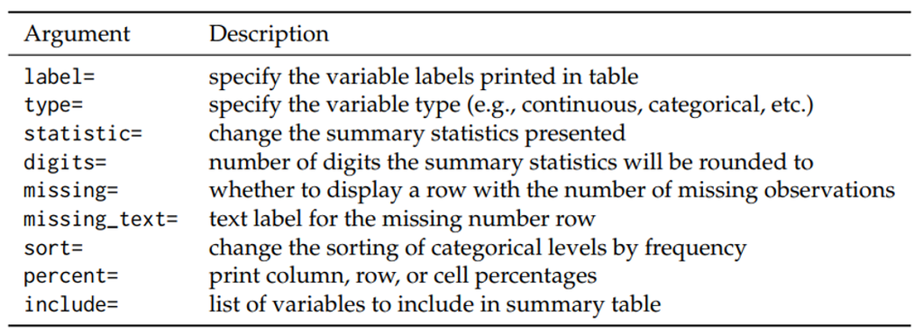

- *add…()*

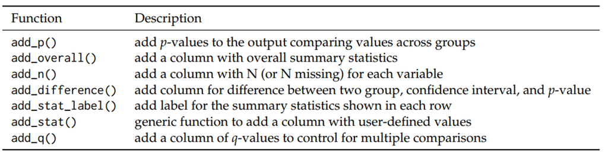

- *format tableau*

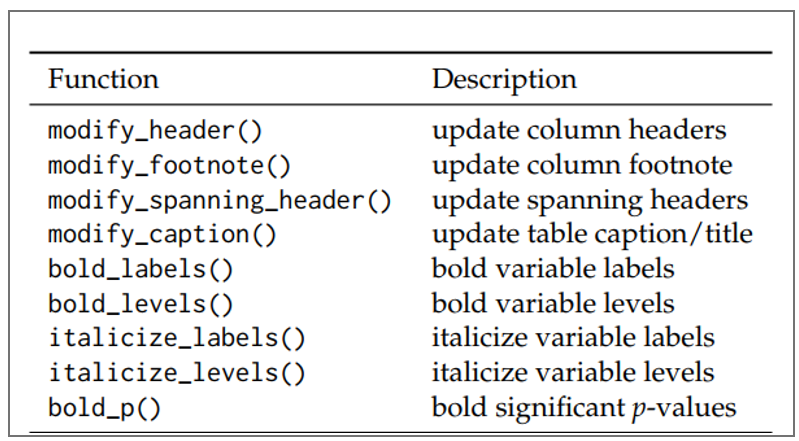

- *Exportation* : gt::gtsave , flextable::save_as_docx

```r
 tableau %>% as_gt() %>%
  gt::gtsave(filename = tbl, path = here::here())

tableau %>%
  as_flex_table() %>%
  flextable::save_as_docx(
    path = paste0(here::here(),"/tbl.docx"))
# tableau est un tableau
# tbl est un fichier word
```

## Bibliographie et webographie

- *https://www.danieldsjoberg.com/gtsummary-weill-cornell-presentation/#59*
- *https://github.com/ddsjoberg/gtsummary*
- *https://www.danieldsjoberg.com/gtsummary/*
- *Reproducible Summary Tables with the gtsummary Package by Daniel D. Sjoberg, Karissa Whiting, Michael Curry, Jessica A. Lavery, Joseph Larmarange*
- *https://larmarange.github.io/analyse-R/gtsummary.html*